# CH 3 MD

Matthew Swanson

20190828

# 1 Data Visualization via ggplot2

We begin the development of your data science toolbox with data visualization.

Graphics provide a nice way for us to get a sense for how quantitative variables compare:

1. **in terms of their center (where data tends is located)**
2. **and their spread (how data varies around the center)**

Examples of quantitative variables: **# of students, age, income**

Also, plots/graphics help us to identify **patterns** and **outliers** in our data.

A common extension of these ideas is to compare the distribution of one quantitative variable as we go across the levels of a different categorical variable.

Examples of categorica variables: **gender, shirt color, major**

# 2 Let’s start by installing and loading the following pacakges

```r
library(nycflights13)   #get the data
library(ggplot2)        #create graphics
library(dplyr)          #we're using it to filter
```

We can break a graphic into the following essential(first three) components:

- `data`: the data-set comprised of variables that we map.
- `geom`: the geometric object in question. This refers to our type of objects we can observe in our plot. For example, points, lines, bars, etc.
- `aes`: aesthetic attributes of the geometric object that we can perceive on a graphic. For example, x/y position, color, shape, and size. Each assigned aesthetic attribute can be mapped to a variable in our data-set.
- `facet` ing breaks up a plot into small multiples corresponding to the levels of another variable (Section 3.6)
- `position` adjustments for barplots (Section 3.8)

Let’s break down the grammar with an example.

We will be considering five different types of graphs.

1. **Scatterplot** *(Find assoc. between 2 quan. vars)*
2. **Linegraph**
3. **Boxplot**
4. **Histogram**
5. **Barplot**

Example: We will graphically investigate the relationship between the following two numerical variables in the `flights` data frame:

1. `dep_delay`: departure delay on the horizontal “x” axis and
2. `arr_delay`: arrival delay on the vertical “y” axis

```r
#View(flights)
data(flights)       #load data frame into session
glimpse(flights)
```

```
## Observations: 336,776
## Variables: 19
## $ year           <int> 2013, 2013, 2013, 2013, 2013, 2013, 2013, 2013, 2…
## $ month          <int> 1, 1, 1, 1, 1, 1, 1, 1, 1, 1, 1, 1, 1, 1, 1, 1, 1…
## $ day            <int> 1, 1, 1, 1, 1, 1, 1, 1, 1, 1, 1, 1, 1, 1, 1, 1, 1…
## $ dep_time       <int> 517, 533, 542, 544, 554, 554, 555, 557, 557, 558,…
## $ sched_dep_time <int> 515, 529, 540, 545, 600, 558, 600, 600, 600, 600,…
## $ dep_delay      <dbl> 2, 4, 2, -1, -6, -4, -5, -3, -3, -2, -2, -2, -2, …
## $ arr_time       <int> 830, 850, 923, 1004, 812, 740, 913, 709, 838, 753…
## $ sched_arr_time <int> 819, 830, 850, 1022, 837, 728, 854, 723, 846, 745…
## $ arr_delay      <dbl> 11, 20, 33, -18, -25, 12, 19, -14, -8, 8, -2, -3,…
## $ carrier        <chr> "UA", "UA", "AA", "B6", "DL", "UA", "B6", "EV", "…
## $ flight         <int> 1545, 1714, 1141, 725, 461, 1696, 507, 5708, 79, …
## $ tailnum        <chr> "N14228", "N24211", "N619AA", "N804JB", "N668DN",…
## $ origin         <chr> "EWR", "LGA", "JFK", "JFK", "LGA", "EWR", "EWR", …
## $ dest           <chr> "IAH", "IAH", "MIA", "BQN", "ATL", "ORD", "FLL", …
## $ air_time       <dbl> 227, 227, 160, 183, 116, 150, 158, 53, 140, 138, …
## $ distance       <dbl> 1400, 1416, 1089, 1576, 762, 719, 1065, 229, 944,…
## $ hour           <dbl> 5, 5, 5, 5, 6, 5, 6, 6, 6, 6, 6, 6, 6, 6, 6, 5, 6…
## $ minute         <dbl> 15, 29, 40, 45, 0, 58, 0, 0, 0, 0, 0, 0, 0, 0, 0,…
## $ time_hour      <dttm> 2013-01-01 05:00:00, 2013-01-01 05:00:00, 2013-0…
```

```r
#str(flights)       #glimpse is better
```

Don’t worry for now if you don’t fully understand what this code is doing, I’ll explain this in details later, just run it all and understand that we are taking all flights and only considering those corresponding to Alaska Airlines.

```r
all_alaska_flights <- flights %>%   #pipe operator
  filter(carrier == "AS")           #filter([expr related to colname])
```

```r
#View(all_alaska_flights)
```

## 2.1 Scatter Plots

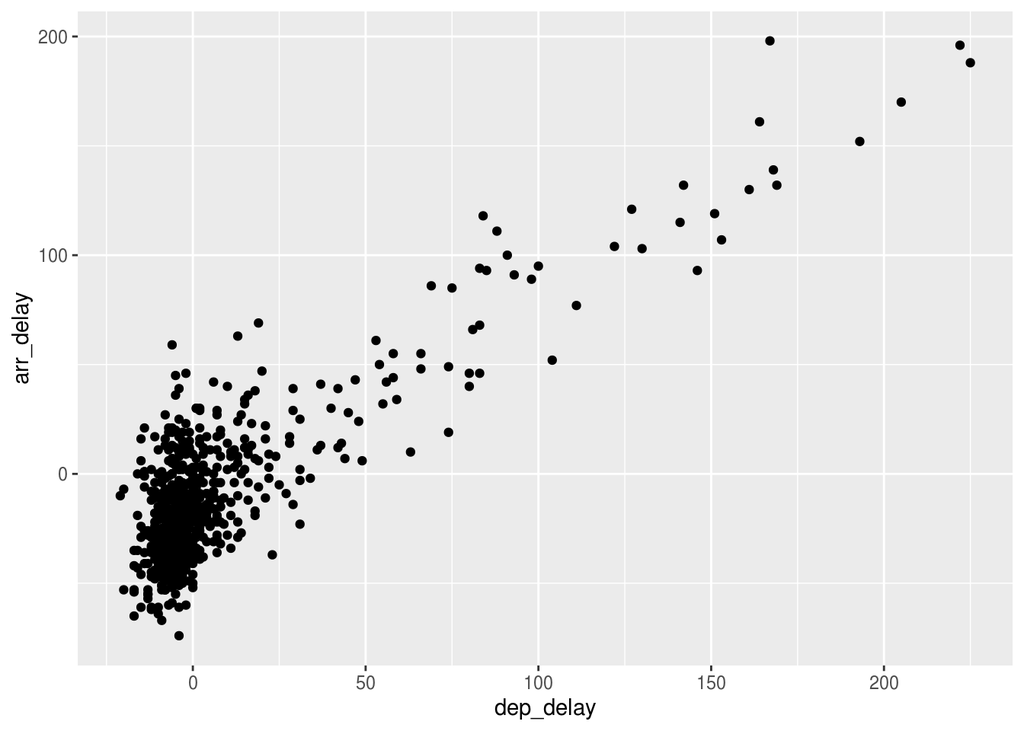

```r
ggplot(data = all_alaska_flights, mapping = aes(x = dep_delay, y = arr_delay)) +
    geom_point()
```

*Positive correlation, with the majority of the data points clustered around the origin.*

The large mass of points near (0, 0) in this scatterplot can cause some confusion. We handle this by…

1. Adjusting the **transparency** of the points via the **`alpha`** argument:

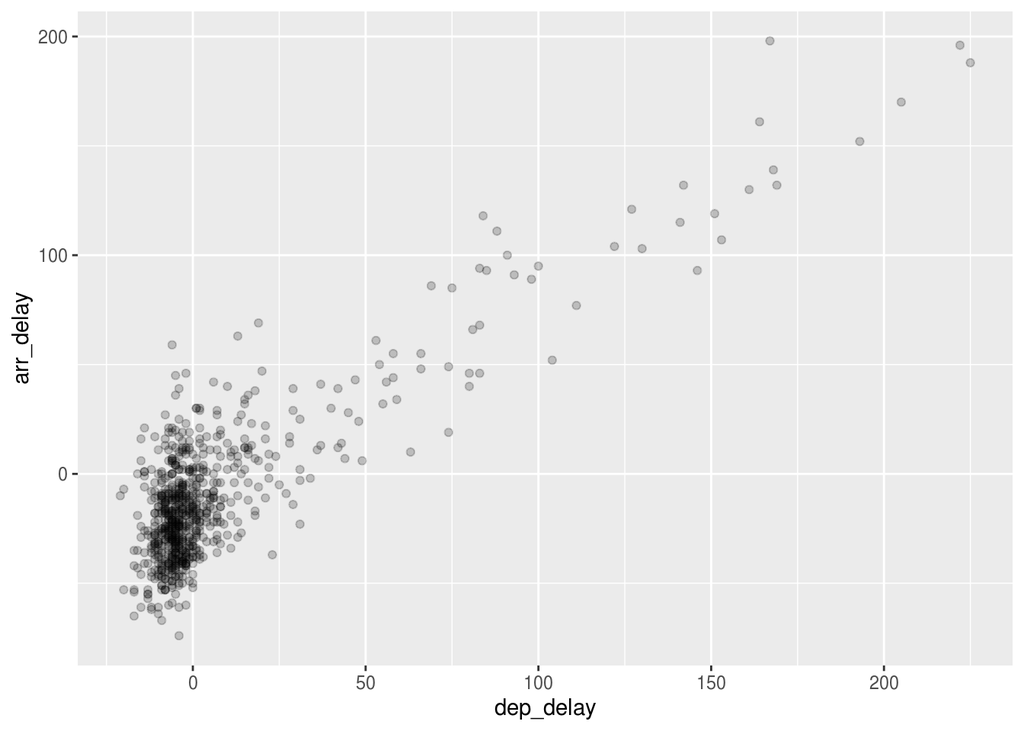

```r
ggplot(data = all_alaska_flights, mapping = aes(x = dep_delay, y = arr_delay)) +
    geom_point(alpha = 0.2)
```

2. Jittering the points via `geom_jitter()`:

Here we are to adding just a bit of random noise to the points to better see them.

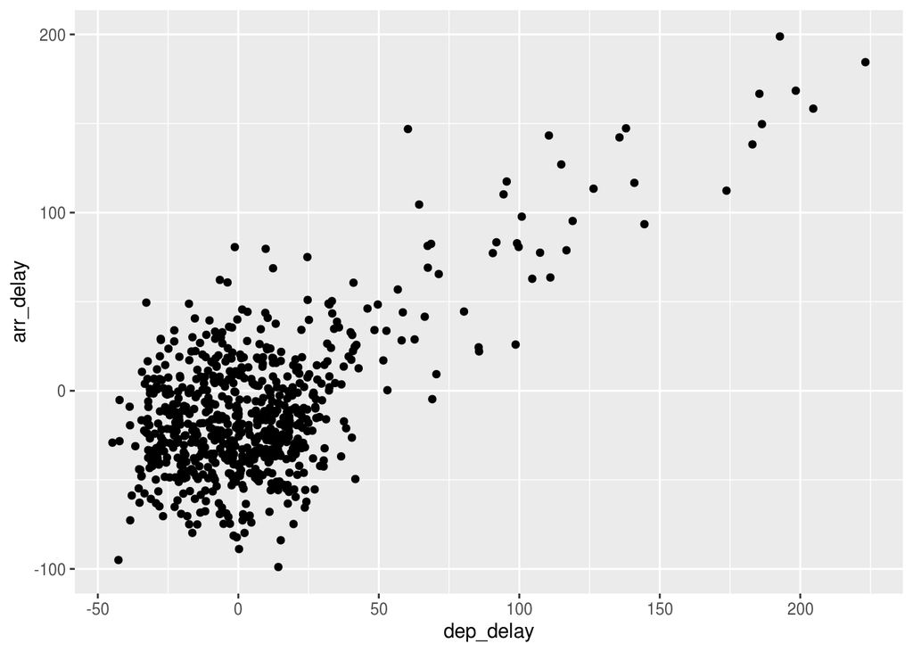

```r
ggplot(data = all_alaska_flights, mapping = aes(x = dep_delay, y = arr_delay)) +
    geom_jitter(width = 30, height = 30)
```

Questions:

1. After viewing the Figure with `alpha` argument above, give an approximate range of arrival delays and departure delays that occur the most frequently.
   - **(-15,-25),(5,5)**
2. How has that region changed compared to when you observed the same plot without the `alpha = 0.2`?
   - **It’s much smaller than when comparing without transparency**

## 2.2 Linegraphs

Explore the `weather` dataset from `nycflights13` package.

```r
#library(nycflights13)   #load the data
#View(weather)           #view the data frame
```

Let’s focus on the hourly temperature at Newark airport (origin code “EWR”) for the first 15 days in January 2013.

```r
early_january_weather <- weather %>%
  filter(origin == "EWR" & month == 1 & day <= 15)
```

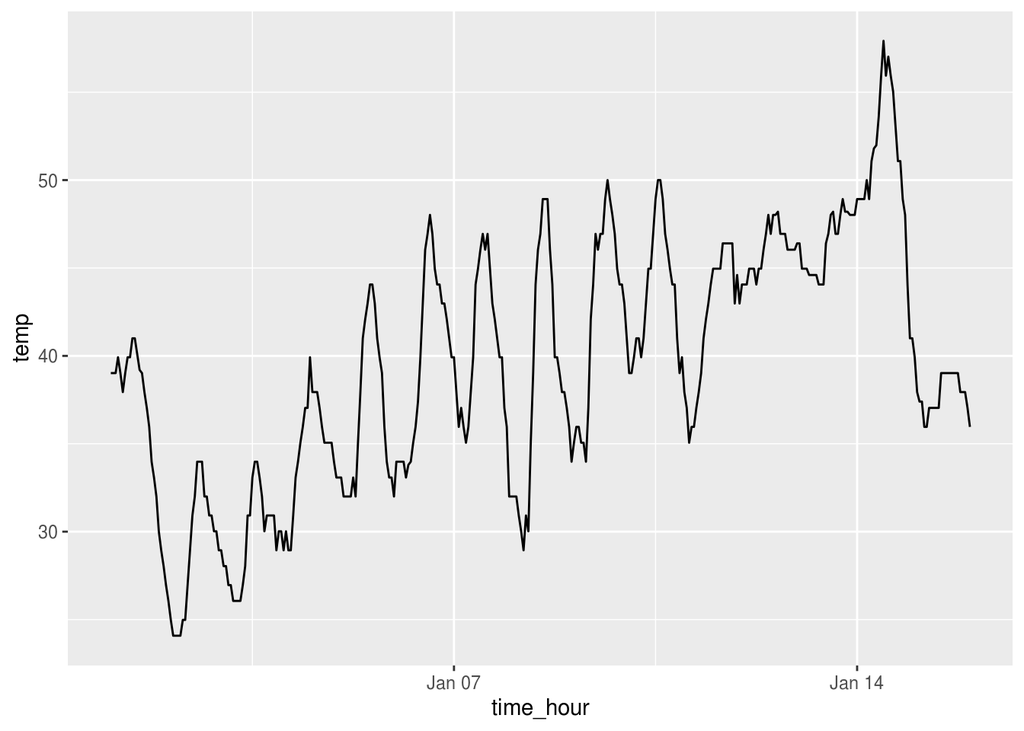

```r
ggplot(data = early_january_weather, mapping = aes(x = time_hour, y = temp)) +
  geom_line()
```

Question:

1. Plot a time series of a variable other than `temp` for Newark Airport in the first 15 days of January 2013.

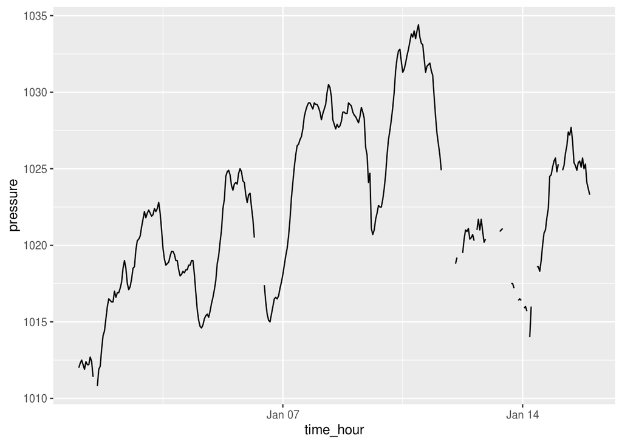

```r
ggplot(data = early_january_weather, mapping = aes(x = time_hour, y = pressure)) +
  geom_line()
```

```r
str(early_january_weather)
```

```
## Classes 'tbl_df', 'tbl' and 'data.frame':    358 obs. of  15 variables:
##  $ origin    : chr  "EWR" "EWR" "EWR" "EWR" ...
##  $ year      : int  2013 2013 2013 2013 2013 2013 2013 2013 2013 2013 ...
##  $ month     : int  1 1 1 1 1 1 1 1 1 1 ...
##  $ day       : int  1 1 1 1 1 1 1 1 1 1 ...
##  $ hour      : int  1 2 3 4 5 6 7 8 9 10 ...
##  $ temp      : num  39 39 39 39.9 39 ...
##  $ dewp      : num  26.1 27 28 28 28 ...
##  $ humid     : num  59.4 61.6 64.4 62.2 64.4 ...
##  $ wind_dir  : num  270 250 240 250 260 240 240 250 260 260 ...
##  $ wind_speed: num  10.36 8.06 11.51 12.66 12.66 ...
##  $ wind_gust : num  NA NA NA NA NA NA NA NA NA NA ...
##  $ precip    : num  0 0 0 0 0 0 0 0 0 0 ...
##  $ pressure  : num  1012 1012 1012 1012 1012 ...
##  $ visib     : num  10 10 10 10 10 10 10 10 10 10 ...
##  $ time_hour : POSIXct, format: "2013-01-01 01:00:00" "2013-01-01 02:00:00" ...
```

## 2.3 Histograms via geom_histogram

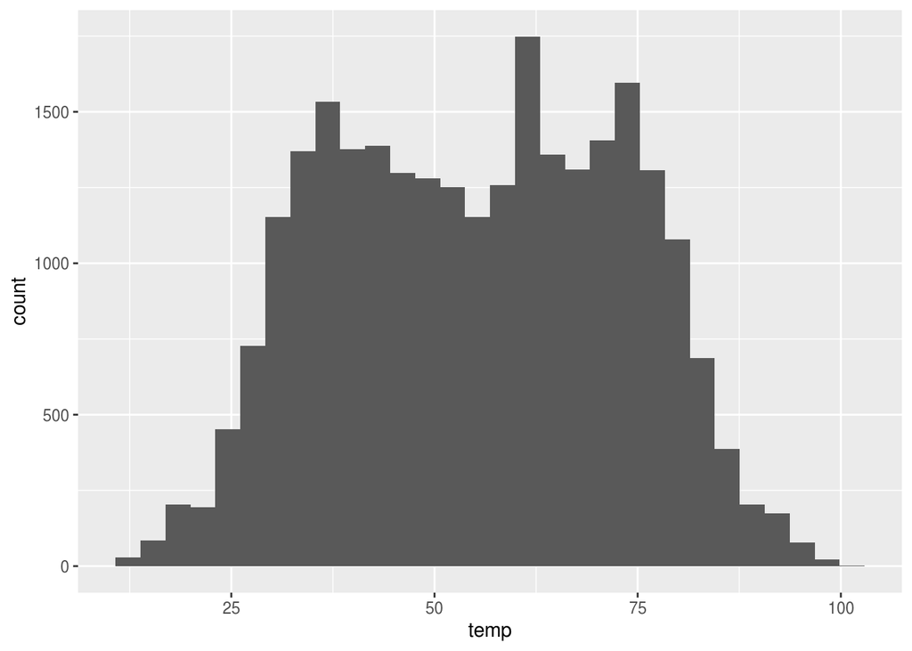

```r
ggplot(data = weather, mapping = aes(x = temp)) +
  geom_histogram()
```

We can adjust characteristics of the bins in one of two ways:

1. By adjusting the number of **bins** via the `bins` argument
2. By adjusting the **bin width** via the `binwidth` argument

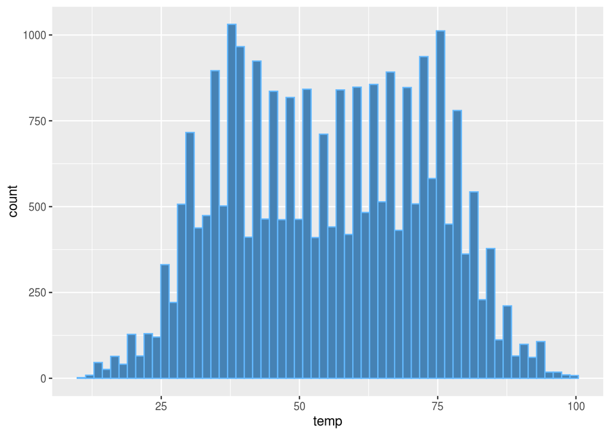

```r
ggplot(data = weather, mapping = aes(x = temp)) +
  geom_histogram(bins = 60, color = "steelblue1", fill = "steelblue")
```

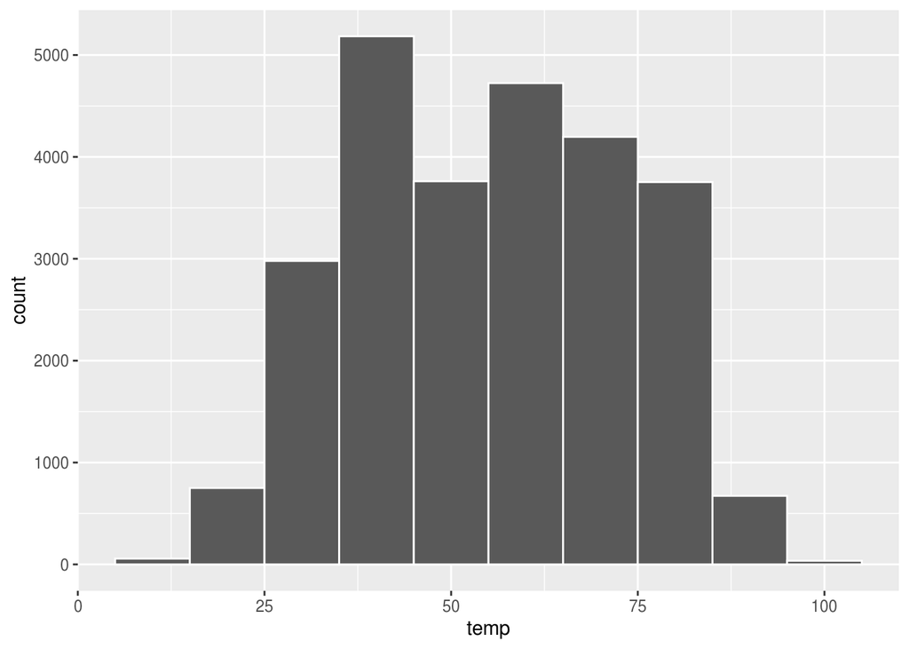

```r
ggplot(data = weather, mapping = aes(x = temp)) +
  geom_histogram(binwidth = 10, color = "white")
```

### 2.3.1 Facets

Suppose we were interested in looking at how the temperature histograms we saw above varied by month.

This is what is meant by “the distribution of a variable over another variable”: `temp` is one variable and `month` is the other variable. In order to look at histograms of `temp` for each `month`, we add a layer `facet_wrap(~ month)`.

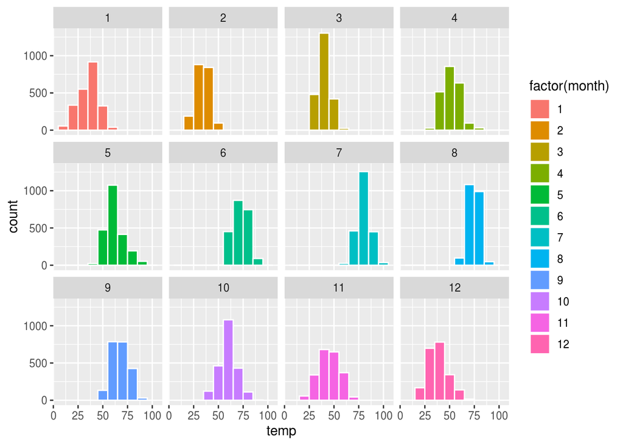

```r
ggplot(data = weather, mapping = aes(x = temp, fill = factor(month))) +
  geom_histogram(binwidth = 10, color = "white") + facet_wrap(~ month)
```

## 2.4 Boxplots via geom_boxplot

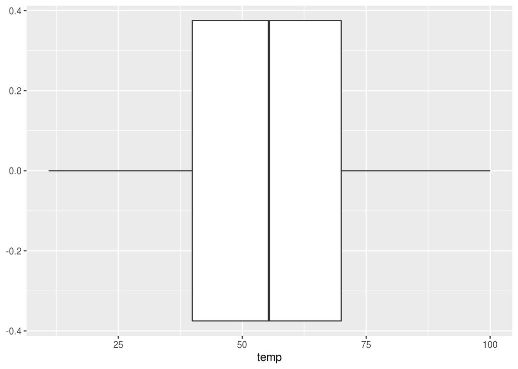

```r
ggplot(data = weather, mapping = aes(y = temp)) +
  geom_boxplot() + coord_flip()
```

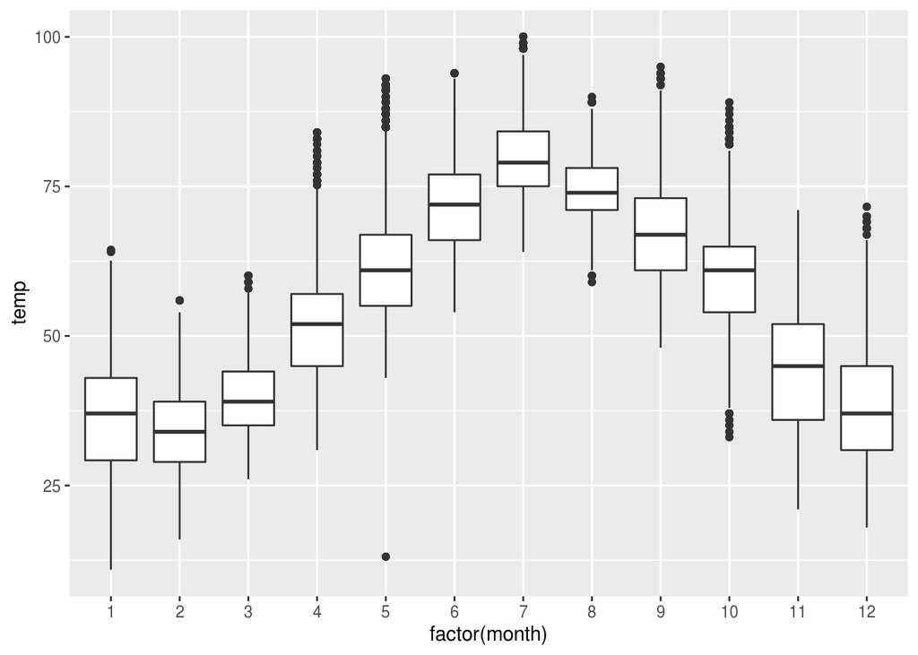

```r
ggplot(data = weather, mapping = aes(x = factor(month), y = temp)) +
  geom_boxplot()
```

*Temperatures are higher–on average– during the months of July and August. Winter months seem to have the highest variability.*

Questions:

1. Which months have the highest variability in temperature? What reasons do you think this is?
   - **Jan, Nov, Dec. More variability in the winter months?**
2. We looked at the distribution of a numerical variable over a categorical variable here with this boxplot. Why can’t we look at the distribution of one numerical variable over the distribution of another numerical variable? Say, temperature across pressure, for example?
   - **Because there would be too many categories; so, not unless we ‘bucket’ the numerical var into effective categories**

## 2.5 Barplots

Both histograms and boxplots represent ways to visualize the variability of numerical variables. Another common task is to present the distribution of a categorical variable. Here we explore the number of flights from each `carrier`.

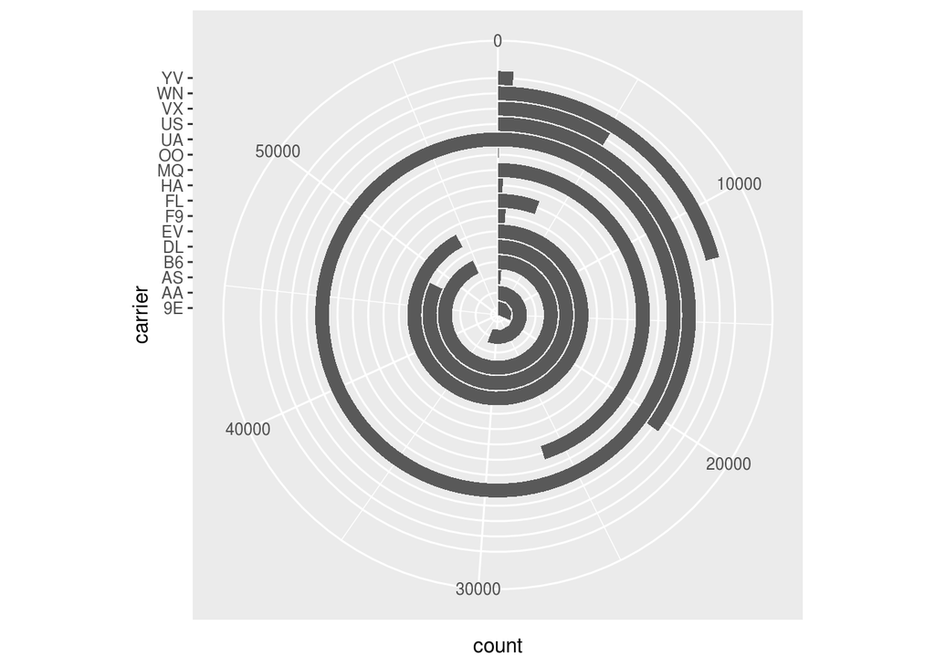

```r
#glimpse(flights)
ggplot(data = flights, mapping = aes(x = carrier)) +
  geom_bar() + coord_polar("y", start=0)
```